# Elastic Net Global Model

From here on out, we’ll only be using the global model and focus specifically on an Elastic Net model; this will better serve our ability to interpret the models.

# Eating Episodes

To predict eating episodes, we have this dataset:

```
       hr             meanrr           sdnn            sdann            sdnnix           pnn50
 Min.   : 63.27   Min.   :446.5   Min.   : 25.86   Min.   : 1.336   Min.   : 22.97   Min.   :0.03982
 1st Qu.: 75.41   1st Qu.:690.5   1st Qu.: 47.06   1st Qu.:12.157   1st Qu.: 42.97   1st Qu.:0.09421
 Median : 82.48   Median :739.9   Median : 55.15   Median :21.897   Median : 53.05   Median :0.12829
 Mean   : 83.40   Mean   :740.6   Mean   : 57.20   Mean   :26.468   Mean   : 55.16   Mean   :0.14826
 3rd Qu.: 87.39   3rd Qu.:799.0   3rd Qu.: 62.08   3rd Qu.:37.885   3rd Qu.: 60.63   3rd Qu.:0.19750
 Max.   :134.82   Max.   :951.7   Max.   :125.16   Max.   :78.542   Max.   :134.48   Max.   :0.28261
      sdsd            rmssd             irrr            madrr           Y
 Min.   : 32.40   Min.   : 32.37   Min.   : 31.25   Min.   : 0.000000   1:14
 1st Qu.: 51.78   1st Qu.: 51.70   1st Qu.: 55.67   1st Qu.: 0.000000   0:14
 Median : 57.38   Median : 57.34   Median : 62.50   Median : 0.000179
 Mean   : 64.62   Mean   : 64.46   Mean   : 68.22   Mean   : 1.674367
 3rd Qu.: 79.77   3rd Qu.: 79.35   3rd Qu.: 69.34   3rd Qu.: 0.000864
 Max.   :125.38   Max.   :124.05   Max.   :125.00   Max.   :15.625477
```

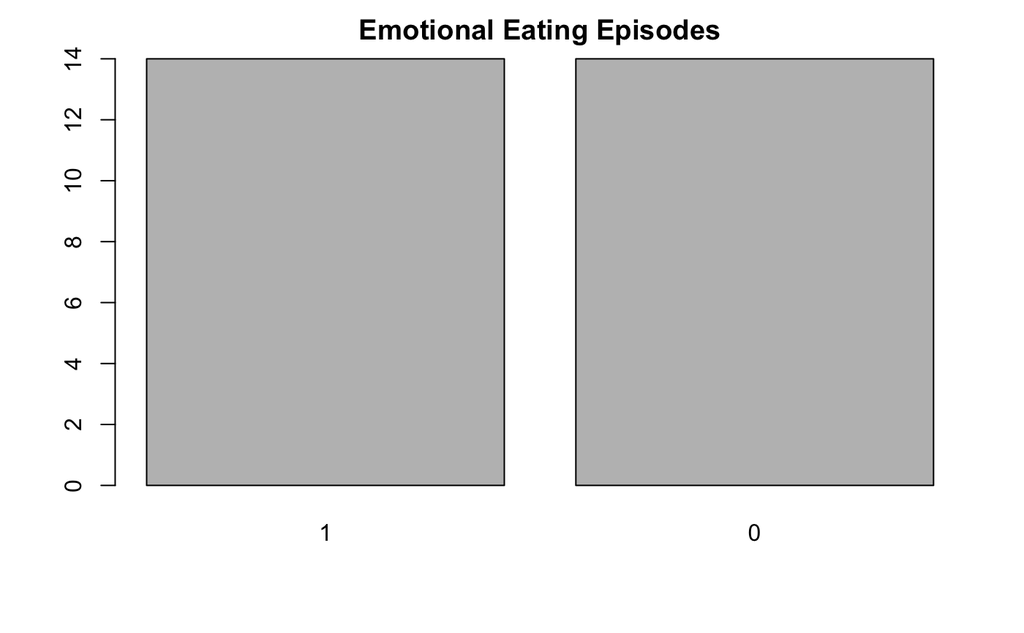

```r
do.call(rbind, hrv_EE)%>%
  select(Y)%>%
  plot(main = "Emotional Eating Episodes")
```

Not a huge data set but it may be enough to work with.

We can examine the model fit specifications for Ridge regression:

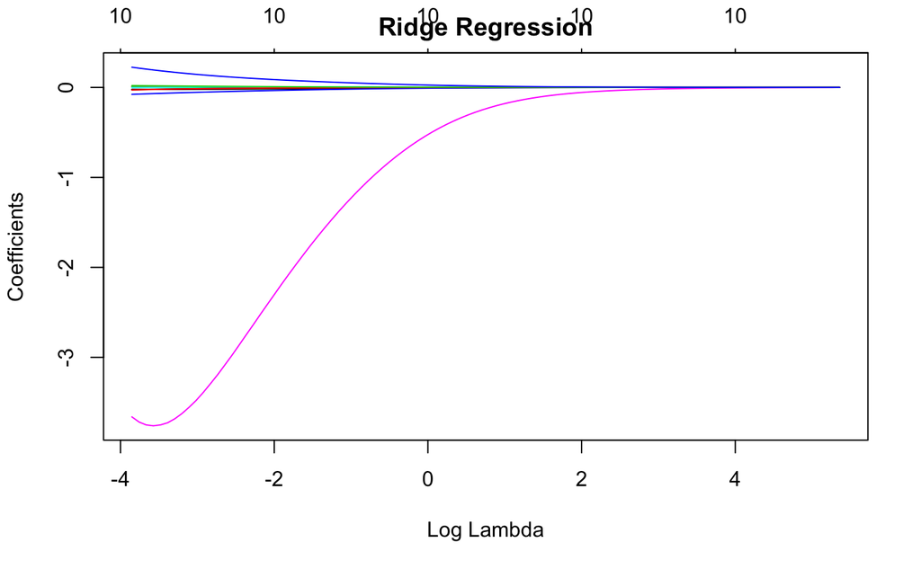

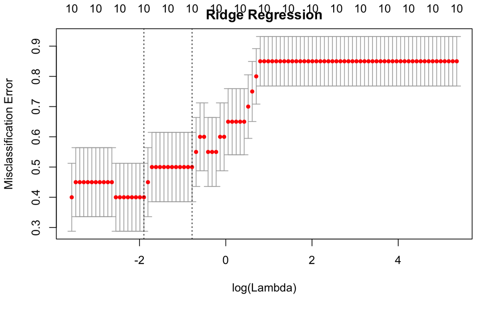

LASSO regression:

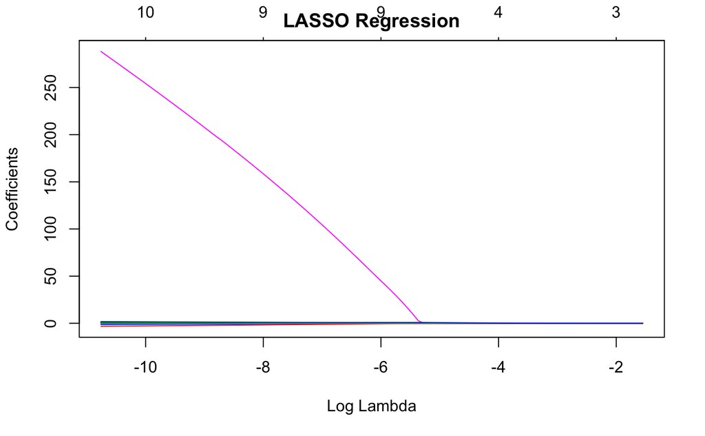

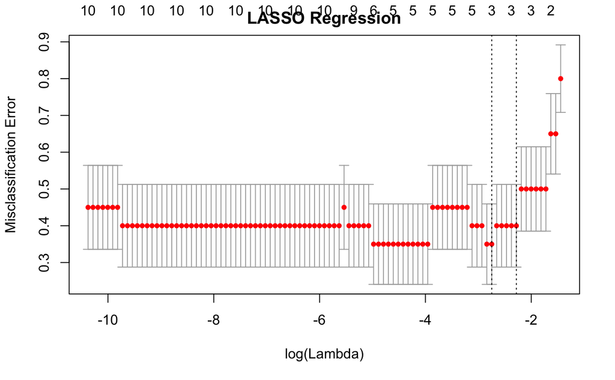

And Elastic Net:

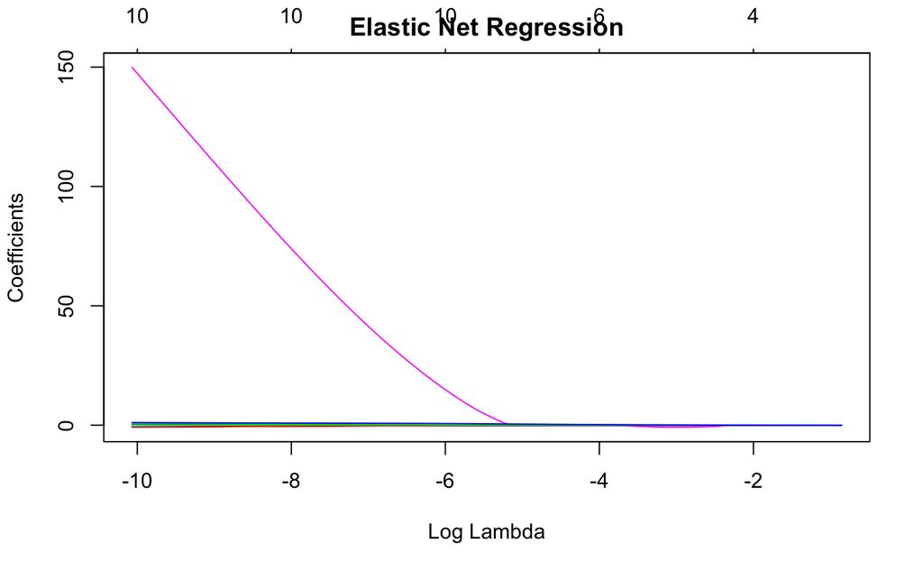

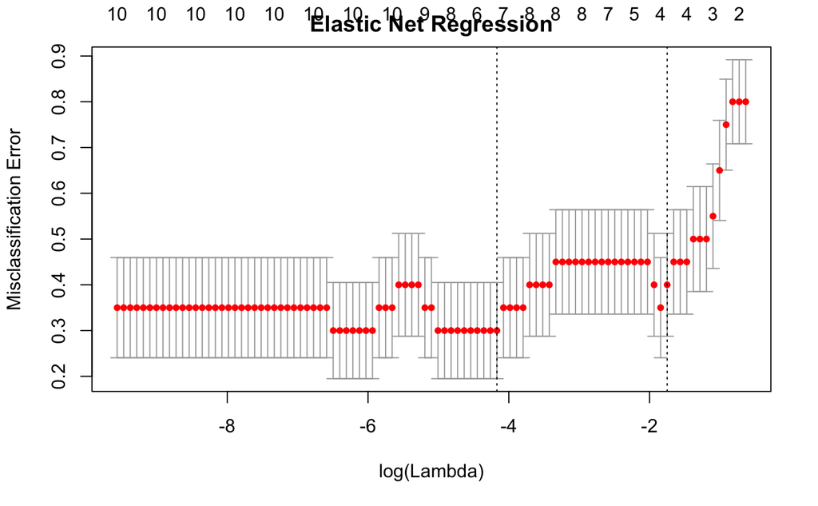

```
----------------------------------------------------------
  &nbsp;     Accuracy   Sensitivity   Specificity   Alpha
----------- ---------- ------------- ------------- -------
 **fit0**     0.625         0.5          0.75         0

 **fit1**     0.625         0.5          0.75        0.1

 **fit2**      0.5          0.5           0.5        0.2

 **fit3**     0.625         0.5          0.75        0.3

 **fit4**     0.625         0.5          0.75        0.4

 **fit5**     0.625         0.5          0.75        0.5

 **fit6**     0.625         0.5          0.75        0.6

 **fit7**     0.625         0.5          0.75        0.7

 **fit8**     0.625         0.5          0.75        0.8

 **fit9**     0.625         0.5          0.75        0.9

 **fit10**     0.75        0.75          0.75         1
----------------------------------------------------------
```

Using the best model we can assess the coefficients:

```
-----------------------------------------------------------------------------
     &nbsp;          fit0        fit1        fit2        fit3        fit4
----------------- ----------- ----------- ----------- ----------- -----------
 **(Intercept)**     -0.23      -0.462      -0.6284     -0.6032     -1.384

     **hr**        -0.009837   -0.007833   -0.006295   -0.000632   -0.003797

   **meanrr**      0.002018    0.001978    0.002088    0.001181    0.003023

    **sdnn**       -0.001461       0           0           0           0

    **sdann**      -0.01649    -0.01766    -0.01891    -0.01093    -0.02507

   **sdnnix**      0.004192    0.0006904       0           0           0

    **pnn50**       -1.042      -0.2827        0           0           0

    **sdsd**       -0.002459       0           0           0           0

    **rmssd**      -0.002521       0           0           0           0

    **irrr**       0.003387    0.0002741       0           0           0

    **madrr**       0.04462     0.0439      0.04504     0.02868     0.05251
-----------------------------------------------------------------------------

Table: Table continues below


-----------------------------------------------------------------------------------
     &nbsp;          fit5       fit6       fit7       fit8       fit9      fit10
----------------- ---------- ---------- ---------- ---------- ---------- ----------
 **(Intercept)**   -0.8211     -2.092     -1.123     -3.776     -2.526     -2.762

     **hr**           0          0          0          0          0          0

   **meanrr**      0.00149    0.00362    0.002032   0.006487   0.004407   0.004824

    **sdnn**          0          0          0          0          0          0

    **sdann**      -0.01371   -0.02701   -0.01784   -0.04542   -0.03269   -0.03548

   **sdnnix**         0          0          0          0          0          0

    **pnn50**         0          0          0          0          0          0

    **sdsd**          0          0          0          0          0          0

    **rmssd**         0          0          0          0          0          0

    **irrr**          0          0          0          0          0          0

    **madrr**      0.03238    0.05106    0.03614    0.06853    0.04886    0.04814
-----------------------------------------------------------------------------------
```

Fit10 is the best model, where only `meanrr`, `sdann`, and `madrr` were selected.

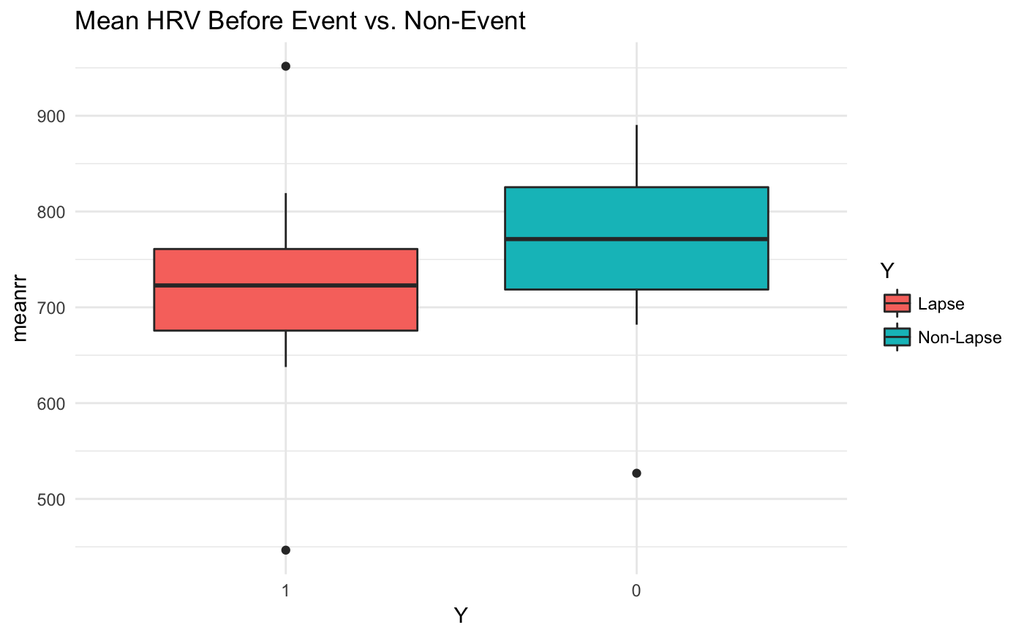

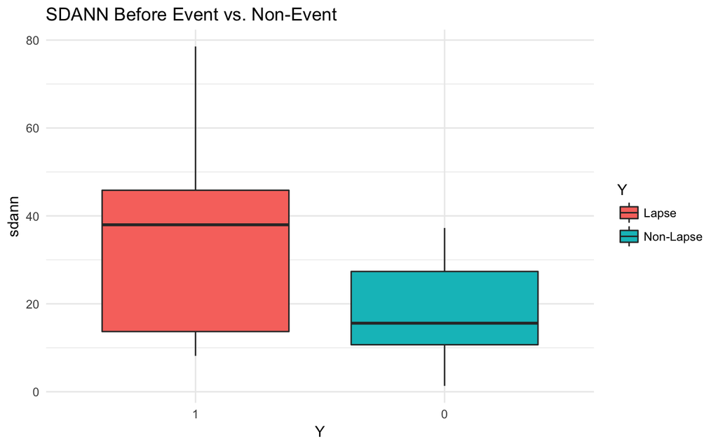

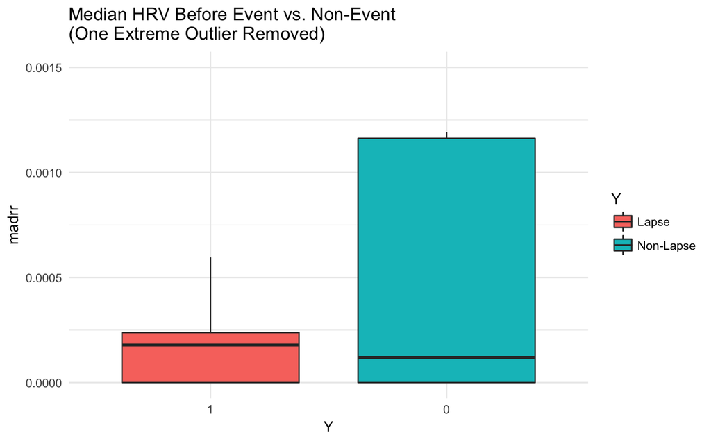

# Urges

To predict urges, we have this dataset:

```
       hr             meanrr           sdnn            sdann              sdnnix           pnn50
 Min.   : 63.27   Min.   :446.5   Min.   : 25.86   Min.   :  0.3547   Min.   : 22.97   Min.   :0.009009
 1st Qu.: 77.06   1st Qu.:690.9   1st Qu.: 48.00   1st Qu.: 13.0851   1st Qu.: 44.11   1st Qu.:0.091278
 Median : 82.96   Median :729.8   Median : 56.15   Median : 24.1771   Median : 51.25   Median :0.132187
 Mean   : 83.24   Mean   :734.6   Mean   : 59.62   Mean   : 28.9750   Mean   : 52.22   Mean   :0.141231
 3rd Qu.: 87.51   3rd Qu.:783.9   3rd Qu.: 66.26   3rd Qu.: 37.3879   3rd Qu.: 59.32   3rd Qu.:0.177443
 Max.   :134.82   Max.   :951.7   Max.   :125.16   Max.   :113.7062   Max.   :134.48   Max.   :0.307692
      sdsd            rmssd             irrr            madrr           Y
 Min.   : 23.73   Min.   : 23.72   Min.   : 31.25   Min.   :-46.87715   1:64
 1st Qu.: 51.85   1st Qu.: 51.79   1st Qu.: 61.52   1st Qu.:  0.00000   0:64
 Median : 62.45   Median : 62.38   Median : 62.50   Median :  0.00024
 Mean   : 65.72   Mean   : 65.47   Mean   : 67.02   Mean   :  0.67159
 3rd Qu.: 76.59   3rd Qu.: 76.40   3rd Qu.: 78.13   3rd Qu.:  0.00060
 Max.   :144.18   Max.   :138.44   Max.   :167.98   Max.   : 15.62607
```

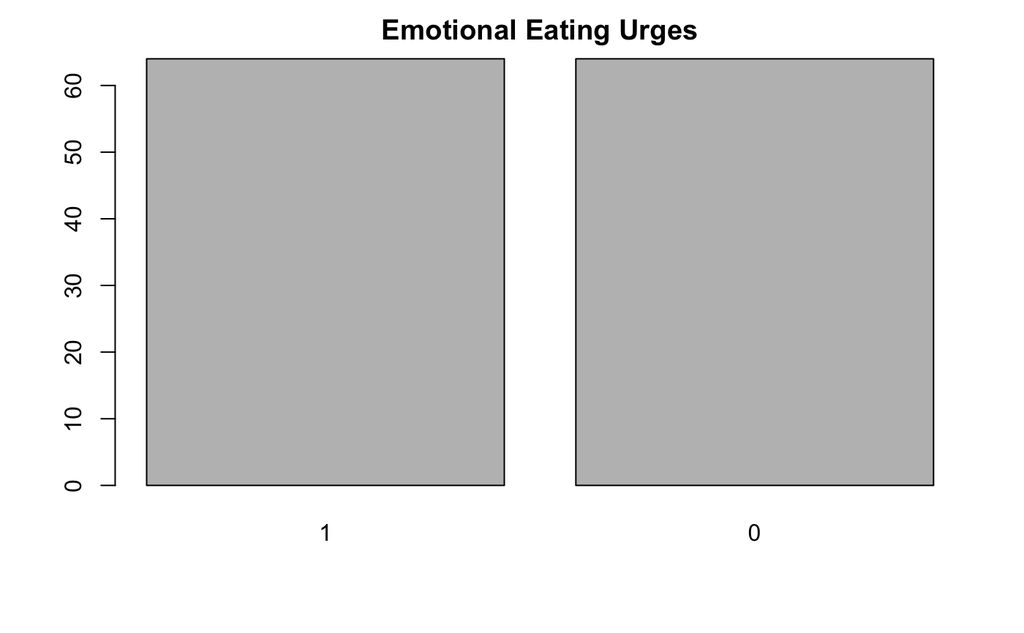

```r
do.call(rbind, hrv_Urge)%>%
  select(Y)%>%
  plot(main = "Emotional Eating Urges")
```

We can examine the model fit specifications for Ridge regression:

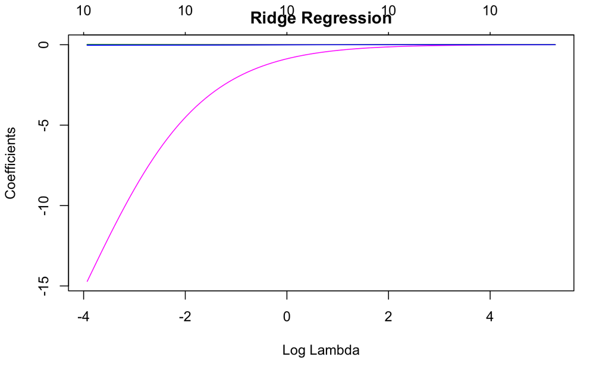

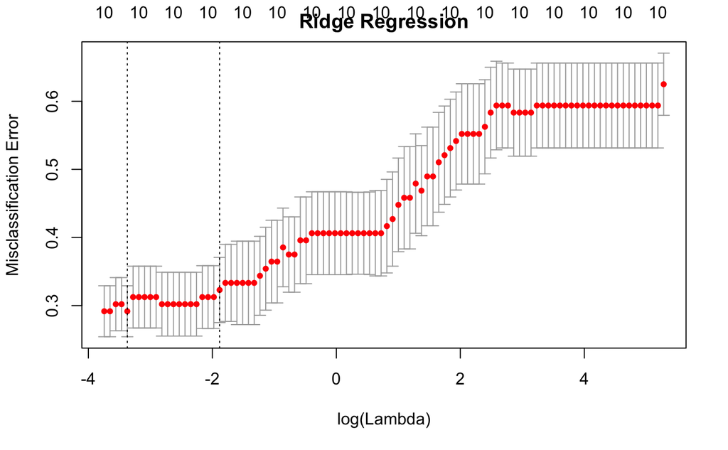

LASSO regression:

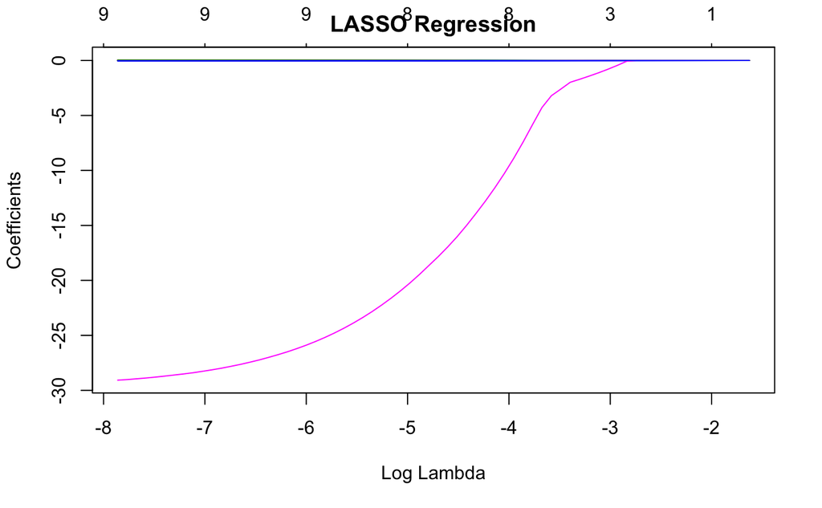

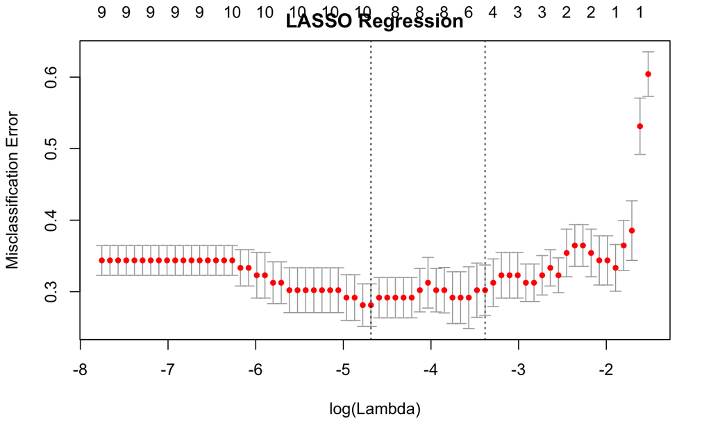

And Elastic Net:

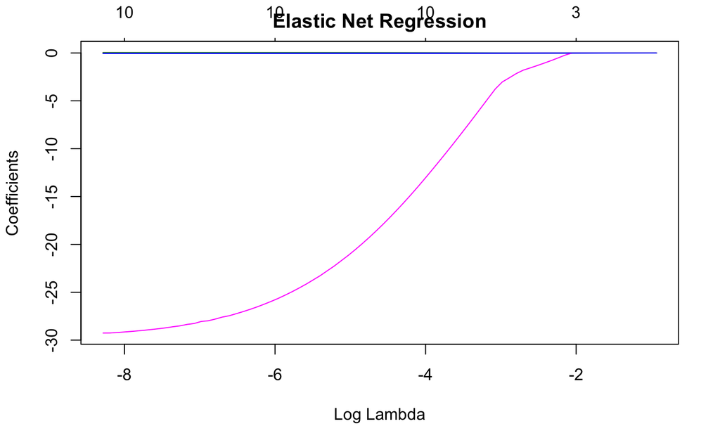

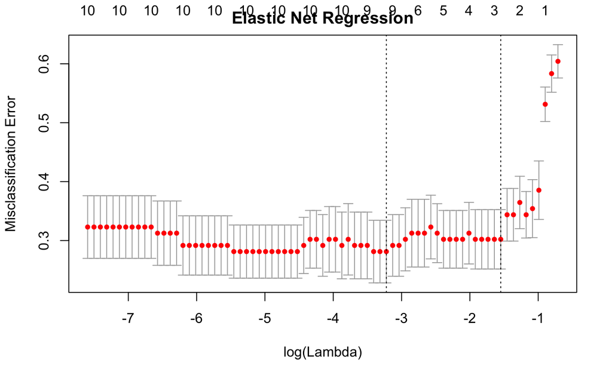

```
----------------------------------------------------------
  &nbsp;     Accuracy   Sensitivity   Specificity   Alpha
----------- ---------- ------------- ------------- -------
 **fit0**     0.5625        0.5          0.625        0

 **fit1**     0.5625        0.5          0.625       0.1

 **fit2**     0.5938        0.5         0.6875       0.2

 **fit3**     0.5625        0.5          0.625       0.3

 **fit4**     0.5625        0.5          0.625       0.4

 **fit5**     0.5625        0.5          0.625       0.5

 **fit6**     0.5938        0.5         0.6875       0.6

 **fit7**     0.5938        0.5         0.6875       0.7

 **fit8**     0.5938        0.5         0.6875       0.8

 **fit9**     0.5938        0.5         0.6875       0.9

 **fit10**    0.5625        0.5          0.625        1
----------------------------------------------------------
```

Not great predictions. We can examine the coefficients for the best model:

```r
l = lapply(urge_glmnet$Model, sparse_to_pander)
for(x in 1:length(l)){
  colnames(l[[x]]) = paste("fit", x-1, sep="")
}
do.call(cbind, l)%>%
  pander()
```

```
----------------------------------------------------------------------------
     &nbsp;          fit0        fit1        fit2       fit3        fit4
----------------- ----------- ----------- ---------- ----------- -----------
 **(Intercept)**    0.2971      0.3897      0.1266     0.1042      0.05176

     **hr**        -0.01955    -0.01582    -0.0067    -0.007575   -0.004119

   **meanrr**      0.002813    0.002338    0.001052   0.001306    0.0009195

    **sdnn**       -0.008891   -0.003571      0           0           0

    **sdann**      -0.02117     -0.0186    -0.0119    -0.01537    -0.01362

   **sdnnix**      0.007847    0.003358       0           0           0

    **pnn50**       -4.139      -1.919     -0.05312   -0.01479        0

    **sdsd**       0.002966    0.0003525      0           0           0

    **rmssd**      0.003029    0.0003451      0           0           0

    **irrr**       0.002524        0          0           0           0

    **madrr**      -0.01772    -0.01091       0           0           0
----------------------------------------------------------------------------

Table: Table continues below


-----------------------------------------------------------------------------
     &nbsp;          fit5        fit6        fit7        fit8        fit9
----------------- ----------- ----------- ----------- ----------- -----------
 **(Intercept)**   -0.08023     -0.2012     -0.5388     -1.659      -3.135

     **hr**        -0.007617   -0.004594   -0.004291   -0.003979       0

   **meanrr**      0.001743    0.001515    0.002059    0.004079     0.00596

    **sdnn**           0           0           0           0           0

```

[output cut: 28 more lines]

```

    **sdann**      -0.02407

   **sdnnix**         0

    **pnn50**         0

    **sdsd**          0

    **rmssd**         0

    **irrr**          0

    **madrr**         0
----------------------------
```

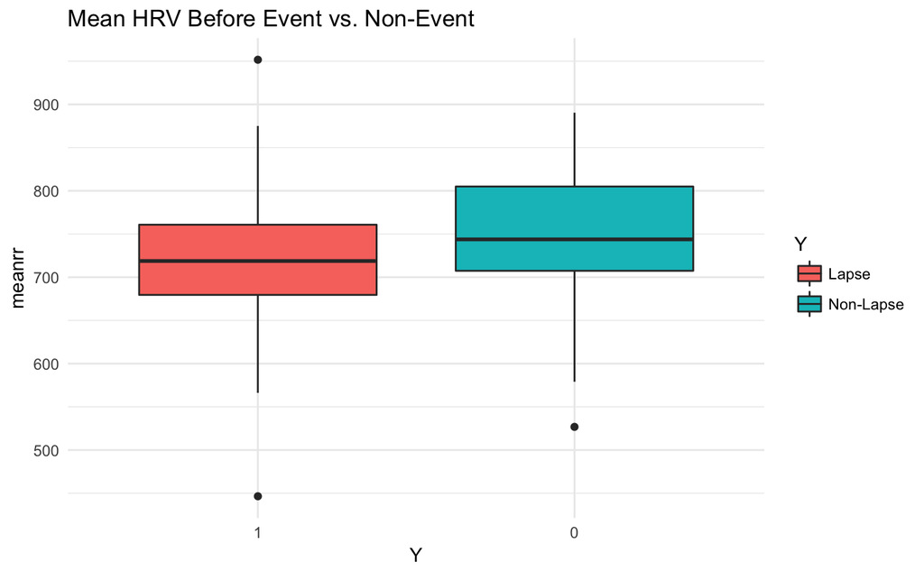

```r
rbind(urge$train, urge$test)%>%
  select(one_of(c("Y", "meanrr")))%>%
  ggplot(aes(x=Y,y=meanrr))+
  geom_boxplot(aes(fill=Y))+
  ggtitle("Mean HRV Before Event vs. Non-Event")+
  scale_fill_discrete(labels = c("Lapse", "Non-Lapse"))+
  theme_minimal()
```

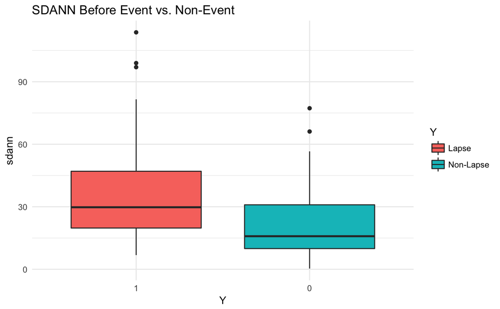

```r
rbind(urge$train, urge$test)%>%
  select(one_of(c("Y", "sdann")))%>%
  ggplot(aes(x=Y,y=sdann))+
  geom_boxplot(aes(fill=Y))+
  ggtitle("SDANN Before Event vs. Non-Event")+
  scale_fill_discrete(labels = c("Lapse", "Non-Lapse"))+
  theme_minimal()
```

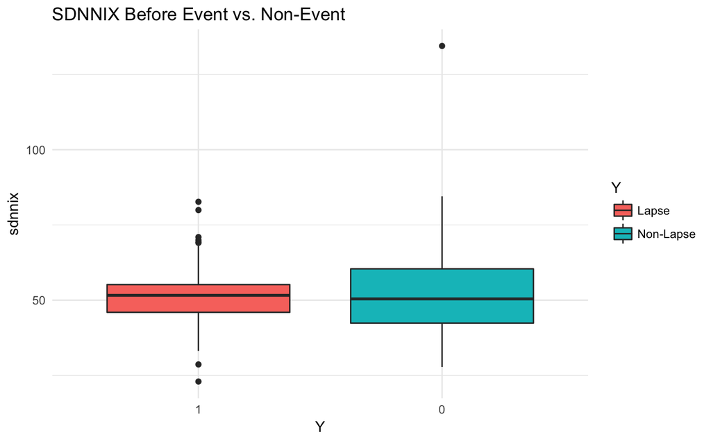

```r
rbind(urge$train, urge$test)%>%
  select(one_of(c("Y", "sdnnix")))%>%
  ggplot(aes(x=Y,y=sdnnix))+
  geom_boxplot(aes(fill=Y))+
  ggtitle("SDNNIX Before Event vs. Non-Event")+
  scale_fill_discrete(labels = c("Lapse", "Non-Lapse"))+
  theme_minimal()
```

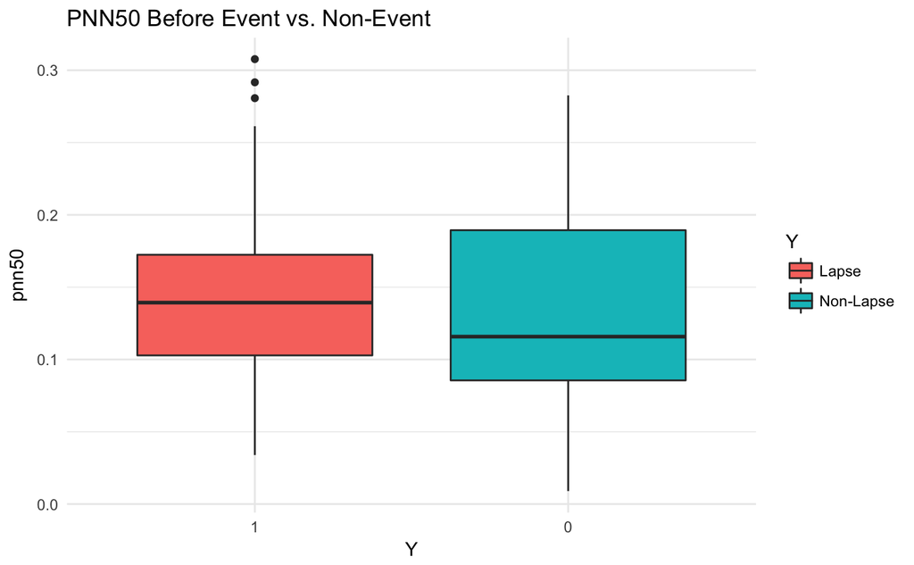

```r
rbind(urge$train, urge$test)%>%
  select(one_of(c("Y", "pnn50")))%>%
  ggplot(aes(x=Y,y=pnn50))+
  geom_boxplot(aes(fill=Y))+
  ggtitle("PNN50 Before Event vs. Non-Event")+
  scale_fill_discrete(labels = c("Lapse", "Non-Lapse"))+
  theme_minimal()
```

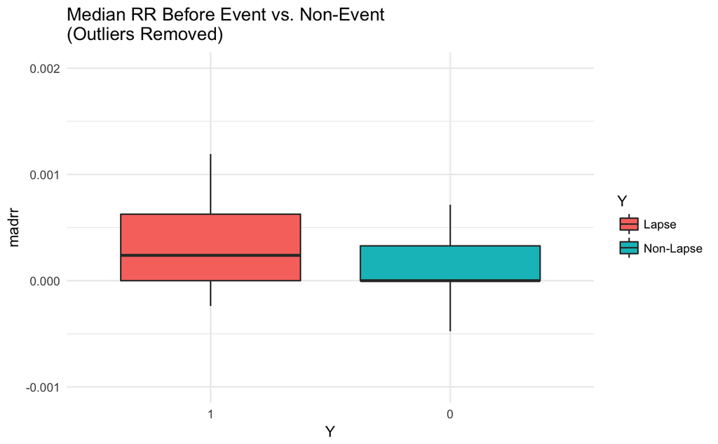

```r
rbind(urge$train, urge$test)%>%
  select(one_of(c("Y", "madrr")))%>%
  ggplot(aes(x=Y,y=madrr))+
  geom_boxplot(aes(fill=Y), outlier.shape = NA )+
  ggtitle("Median RR Before Event vs. Non-Event\n(Outliers Removed)")+
  scale_fill_discrete(labels = c("Lapse", "Non-Lapse"))+
  theme_minimal()+
  coord_cartesian(ylim = c(-0.001,0.002))
```

Let’s use the other models to see if anything better happened.

# Other models just for kicks

```r
urge_results%>%pander()
```

```
--------------------------------------
 Accuracy   Sensitivity   Specificity
---------- ------------- -------------
  0.625       0.4375        0.8125

  0.5312      0.4375         0.625

   0.5           0             1

   0.5        0.5625        0.4375

  0.625       0.4375        0.8125

  0.6562      0.5625         0.75
--------------------------------------
```

Still not great.